# 线性回归

22920242203150 2025-12-21

课程代码均在如下 GitHub 仓库开源：https://github.com/GHe0000/scientific-programming-intro

## 目录

- 作业要求
- 数据清洗和处理
- 模型构建和损失函数定义
- 正规方程+L2正规化求解
- 梯度下降训练
- 超参优化
  - 多项式阶数
  - L2 正则化系数
  - 学习率
- 结果可视化和结论
- 结论
- 参考资料
- 致谢
- 附一：问题
- 附二：学习心得

## 作业要求

对 “2019Happy.csv” 数据进行线性回归分析，要求：

- 按上课讲的流程分步骤进行
- 利用 Normal equation + L2 进行训练
- 利用梯度下降训练（可选）
- 寻找最优的 $\lambda$ 系数
- 可视画结果
- 分析结果，哪些因素影响幸福指数？

## 数据清洗和处理

导入需要的库，并针对 Jupyter Notebook 进行一些设置.

```python
import numpy as np # 数值计算库
import numba as nb # 引入 jit 来加速函数（如果需要）
import sympy as sym # 符号计算库
import matplotlib as mpl
import matplotlib.pyplot as plt # 图像绘制
from matplotlib.backends.backend_agg import FigureCanvasAgg # 设置图像后端用
import ipywidgets as ipw # 交互控件
from IPython.display import display, Math, Latex # 打印数学公式
import time
import tracemalloc

import matplotlib.animation as animation # 创建动画
from IPython.display import HTML # 动画嵌入
import scipy
import pandas as pd
from itertools import combinations_with_replacement

from sklearn.linear_model import RANSACRegressor
from scipy.spatial import cKDTree

# 使用 mathjax 来在 jupyter notebook 显示数学公式
sym.init_printing(use_latex='mathjax')

# 设置 matplotlib 绘制的图像嵌入到 jupyter notebook 的方式
%matplotlib widget

# 一个工具函数，可以让静态图片不经过 widget 直接嵌入 Jupyter notebook
# 这样图片可以直接存到 nb 文件里，而不是需要运行才能显示（类似 inline）
def display_inline(fig):
    fig.set_canvas(FigureCanvasAgg(fig))
    display(fig)
    plt.close(fig) # 释放 fig，减小资源消耗

# 一个工具函数，用于在 Jupyter 中快速实现公式和字符串混合输出
def display_math(*args):
    parts = []
    for a in args:
        if isinstance(a, str):
            parts.append(a)
        else:
            parts.append(sym.latex(a))
    display(Math("".join(parts)))

# 设置 matplotlib 使用的字体，避免出现中文问题
plt.rcParams['font.family'] = ['SimSun', 'Times New Roman']
plt.rcParams['mathtext.fontset'] = 'cm'
# 设置默认坐标轴字体大小
plt.rcParams['axes.labelsize'] = 14

# 设置种子，保证可重复性
np.random.seed(3407)
```

读取 csv 数据，并显示前 15 条数据：

```python
df = pd.read_csv('2019Happy.csv')
df.head(15)
```

|  | Overall rank | Country or region | Score | GDP per capita | Social support | Healthy life expectancy | Freedom to make life choices | Generosity | Perceptions of corruption |
| --- | --- | --- | --- | --- | --- | --- | --- | --- | --- |
| 0 | 1 | Finland | 7.769 | 1.340 | 1.587 | 0.986 | 0.596 | 0.153 | 0.393 |
| 1 | 2 | Denmark | 7.600 | 1.383 | 1.573 | 0.996 | 0.592 | 0.252 | 0.410 |
| 2 | 3 | Norway | 7.554 | 1.488 | 1.582 | 1.028 | 0.603 | 0.271 | 0.341 |
| 3 | 4 | Iceland | 7.494 | 1.380 | 1.624 | 1.026 | 0.591 | 0.354 | 0.118 |
| 4 | 5 | Netherlands | 7.488 | 1.396 | 1.522 | 0.999 | 0.557 | 0.322 | 0.298 |
| 5 | 6 | Switzerland | 7.480 | 1.452 | 1.526 | 1.052 | 0.572 | 0.263 | 0.343 |
| 6 | 7 | Sweden | 7.343 | 1.387 | 1.487 | 1.009 | 0.574 | 0.267 | 0.373 |
| 7 | 8 | New Zealand | 7.307 | 1.303 | 1.557 | 1.026 | 0.585 | 0.330 | 0.380 |
| 8 | 9 | Canada | 7.278 | 1.365 | 1.505 | 1.039 | 0.584 | 0.285 | 0.308 |
| 9 | 10 | Austria | 7.246 | 1.376 | 1.475 | 1.016 | 0.532 | 0.244 | 0.226 |
| 10 | 11 | Australia | 7.228 | 1.372 | 1.548 | 1.036 | 0.557 | 0.332 | 0.290 |
| 11 | 12 | Costa Rica | 7.167 | 1.034 | 1.441 | 0.963 | 0.558 | 0.144 | 0.093 |
| 12 | 13 | Israel | 7.139 | 1.276 | 1.455 | 1.029 | 0.371 | 0.261 | 0.082 |
| 13 | 14 | Luxembourg | 7.090 | 1.609 | 1.479 | 1.012 | 0.526 | 0.194 | 0.316 |
| 14 | 15 | United Kingdom | 7.054 | 1.333 | 1.538 | 0.996 | 0.450 | 0.348 | 0.278 |

虽然对于这个数据集大概率没有缺值（类似 Kaggle Titanic 数据集那样可能会有缺值的情况）. 但为了保险起见，我们还是检查一下：

```python
print(df.isnull().sum())
```

```
Overall rank                    0
Country or region               0
Score                           0
GDP per capita                  0
Social support                  0
Healthy life expectancy         0
Freedom to make life choices    0
Generosity                      0
Perceptions of corruption       0
dtype: int64
```

可见没有空值.

这里我们令 Score 为 $y$，GDP per capita、Social support 等分别是 $x_1$ 到 $x_6$. 我们的目标是构建函数 $y=f(x_1,\dots,x_6)$.

我们按 $80%-20%$ 划分训练集和测试集. 训练集/测试集随机划分. 并打印训练集/测试集数量

```python
all_features = ['GDP per capita', 'Social support', 'Healthy life expectancy',
                'Freedom to make life choices', 'Generosity', 'Perceptions of corruption']
X_raw = df[all_features].values
y_raw = df['Score'].values.reshape(-1, 1)
select_idx = np.random.permutation(len(X_raw))
n_train = int(0.8 * len(X_raw))
X_train_raw, X_test_raw = X_raw[select_idx[:n_train]], X_raw[select_idx[n_train:]]
y_train, y_test = y_raw[select_idx[:n_train]], y_raw[select_idx[n_train:]]

print(f"训练集大小: {len(y_train)}")
print(f"测试集大小: {len(y_test)}")
```

```
训练集大小: 124
测试集大小: 32
```

## 模型构建和损失函数定义

这里我们考虑多项式拟合，我们给定一个多项式阶数 `degree`，并构建特征：

对于 $x^{(i)}_1$ 到 $x^{(i)}_6$. 有特征：

$$ [1, x^{(i)}_1, x^{(i)}_2, \dots, {x^{(i)}_1}^2, x^{(i)}_1 x^{(i)}_2, \dots] $$

这里我们对特征进行标准化，也就是：

$$ x^{(i)}_{norm} = \frac{x^{(i)}-\mu}{\sigma} $$

其中 $x^{(i)}$ 为某数据特征的第 $i$ 个值. $\mu$ 为该列的平均值，$\sigma$ 是该列的标准差.

```python
def calc_mu_sigma(X, degree):
    m, n = X.shape
    features = []
    for d in range(1, degree + 1):
        for c in combinations_with_replacement(range(n), d):
            tmp = np.prod(X[:, c], axis=1).reshape(-1, 1)
            features.append(tmp)
    X_feat = np.hstack(features)
    mu = np.mean(X_feat, axis=0)
    sigma = np.std(X_feat, axis=0)
    return mu, sigma

def gen_features(X, degree, mu, sigma):
    m, n = X.shape
    feat = []
    for d in range(1, degree + 1):
        for c in combinations_with_replacement(range(n), d):
            tmp = np.prod(X[:, c], axis=1).reshape(-1, 1)
            feat.append(tmp)
    X_feat = np.hstack(feat)
    X_feat_std = (X_feat - mu) / sigma
    bias = np.ones((m, 1))
    return np.hstack([bias, X_feat_std])
```

这里模型的评估使用 MSE，即：

$$ J(w) = \frac{1}{n} (y_{pred}-y)^T (y_{pred}-y) $$

训练中使用的损失函数选择 MSE + L2 正则化：

$$L(w) = \frac{1}{2} J(w) + \frac{\lambda}{2} \sum_{j=1}^n w_j^2$$

实现如下：

```python
def MSE(y, y_pred):
    y, y_pred = y.flatten(), y_pred.flatten()
    diff = y_pred - y
    return np.dot(diff, diff) / len(y)

def loss(y, y_pred, lamda, W):
    y, y_pred = y.flatten(), y_pred.flatten()
    mse = np.dot(y_pred - y, y_pred - y) / (2 * len(y))
    l2 = (lamda / 2) * np.dot(W[1:], W[1:])
    return mse + l2
```

这里我们给出推理部分函数，W 为权重. 输入特征，输出预测值

```python
def predict(X, W, degree, mu, sigma):
    X_features = gen_features(X, degree, mu, sigma)
    y_pred = X_features @ W
    return y_pred.reshape(-1, 1)
```

## 正规方程+L2正规化求解

根据课件方程，有 $W$ 满足：

```python
def solve_W(X_train, y_train, degree, lamda):
    mu, sigma = calc_mu_sigma(X_train, degree)
    X = gen_features(X_train_raw, degree, mu, sigma)
    XT = X.T
    C = np.dot(XT, X)
    L = lamda * np.identity(X.shape[1])
    L[0, 0] = 0
    F = C + L
    B = np.linalg.pinv(F)
    D = np.dot(B, XT)
    W = np.dot(D, y_train)
    return W.flatten(), mu, sigma
```

degree 取 2. L2 正则化系数取 0.1. 训练集 MSE 和 测试集 MSE 得：

```python
degree = 2
lamda = 0.1

W_opt, mu, sigma = solve_W(X_train_raw, y_train, degree, lamda)

y_train_pred = predict(X_train_raw, W_opt, degree, mu, sigma)
y_test_pred = predict(X_test_raw, W_opt, degree, mu, sigma)

train_mse = MSE(y_train, y_train_pred)
test_mse = MSE(y_test, y_test_pred)

print(f"degree={degree}, lambda={lamda}")
print(f"训练集 MSE: {train_mse:.6f}")
print(f"测试集 MSE: {test_mse:.6f}")
```

```
degree=2, lambda=0.1
训练集 MSE: 0.186564
测试集 MSE: 0.319832
```

## 梯度下降训练

下面我们使用梯度下降进行训练. 这里我们使用梯度下降法. 对于 MSE：

$$ MSE = \frac{1}{2n} (XW-y)^T(XW-y) $$

MSE 对 W 的梯度为：

$$ \nabla MSE(W) = \frac{1}{2n} \cdot 2 X^T (XW-y) = \frac{1}{n} X^T (y_{pred}-y) $$

L2 正则化为：

$$L_2(W) = \frac{\lambda}{2} W^T W $$

对 W 梯度：

$$ \nabla L_2 (W) = \lambda W $$

则梯度下降为：

$$ W \to W - \alpha (\nabla MSE(W) + \nabla L_2(W)) $$

这里训练数据量比较小，因此不像其他数据集那样分 batch 进行训练，而是每一次参数更新都使用全量的数据.

给定训练次数，并记录 Loss. 每 10 次计算一次预测集 MSE. 返回训练结果：

```python
def train(X_train, y_train, X_test, y_test, degree, lr, epochs, lamda):
    mu, sigma = calc_mu_sigma(X_train, degree)
    X_train_feat = gen_features(X_train, degree, mu, sigma)
    X_test_feat = gen_features(X_test, degree, mu, sigma)

    n, m = X_train_feat.shape
    W = np.zeros(m)
    train_loss_hist, test_mse_hist = [], []
    y_tr_flat, y_te_flat = y_train.flatten(), y_test.flatten()

    for i in range(epochs):
        y_pred = X_train_feat @ W
        curr_loss = loss(y_tr_flat, y_pred, lamda, W)
        train_loss_hist.append(curr_loss)
        grad = (X_train_feat.T @ (y_pred - y_tr_flat)) / n
        W_reg = np.copy(W)
        W_reg[0] = 0
        grad += lamda * W_reg
        W -= lr * grad
        if i % 10 == 0:
            te_pred = X_test_feat @ W
            mse_val = MSE(y_te_flat, te_pred)
            test_mse_hist.append((i, mse_val))
    return W, mu, sigma, train_loss_hist, test_mse_hist
```

这里我们先人为假定阶数 `degree` 为 2. 学习率 0.01, 训练轮数 500. L2 正则化系数 0.1.

绘制训练集 Loss 曲线和测试集 MSE 曲线

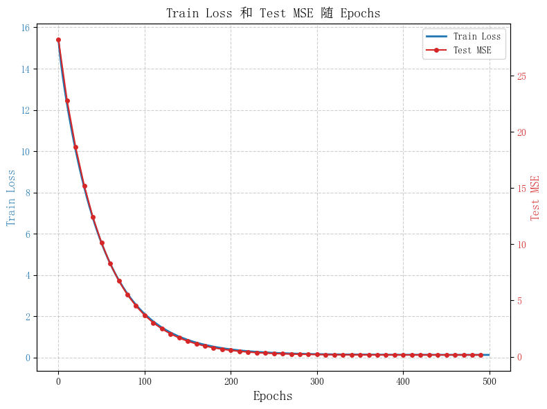

```python
degree = 2
W, mu, sigma, train_loss, test_mse = train(X_train_raw, y_train, X_test_raw, y_test,
                                          degree=degree, lr=0.01, epochs=500, lamda=0.1)

iters, mses = zip(*test_mse)

fig, ax1 = plt.subplots(figsize=(8, 6))

color1 = 'tab:blue'
ax1.set_xlabel('Epochs')
ax1.set_ylabel('Train Loss', color=color1, fontsize=12)
ax1.plot(range(len(train_loss)), train_loss, color=color1, linewidth=2, label='Train Loss')
ax1.tick_params(axis='y', labelcolor=color1)
ax1.grid(True, linestyle='--', alpha=0.6)

ax2 = ax1.twinx()
color2 = 'tab:red'
ax2.set_ylabel('Test MSE', color=color2, fontsize=12)
ax2.plot(iters, mses, color=color2, marker='o', markersize=4, linestyle='-', label='Test MSE')
ax2.tick_params(axis='y', labelcolor=color2)

plt.title('Train Loss 和 Test MSE 随 Epochs', fontsize=14)

lines1, labels1 = ax1.get_legend_handles_labels()
lines2, labels2 = ax2.get_legend_handles_labels()
ax1.legend(lines1 + lines2, labels1 + labels2, loc='upper right')

fig.tight_layout()
display_inline(fig)
```

可见最后训练集 Loss 和测试集 MSE 都下降到一个稳定值. 基本已经收敛.

下面我们计算此时的训练集 MSE 和测试集 MSE：

```python
y_train_pred = predict(X_train_raw, W, degree, mu, sigma)
y_test_pred = predict(X_test_raw, W, degree, mu, sigma)

train_mse = MSE(y_train, y_train_pred)
test_mse = MSE(y_test, y_test_pred)

print(f"degree={degree}, lambda={lamda}")
print(f"训练集 MSE: {train_mse:.6f}")
print(f"测试集 MSE: {test_mse:.6f}")
```

```
degree=2, lambda=0.1
训练集 MSE: 0.257678
测试集 MSE: 0.161777
```

前文正规方程得到的测试集 MSE 为 0.319832, 这里为 0.161777. 梯度下降法得到的结果比正规方程+L2正则化略好

## 超参优化

前面的模型中主要有几个超参：多项式阶数 degree, L2 正则化系数 $\lambda$.

### 多项式阶数

这里我们使用正规方程+L2 正则化解析求解的方式进行求解. 先固定 $\lambda=0.1$. 我们改变多项式的 degree. 并绘制训练集 MSE 和测试集 MSE 随 degree 变化：

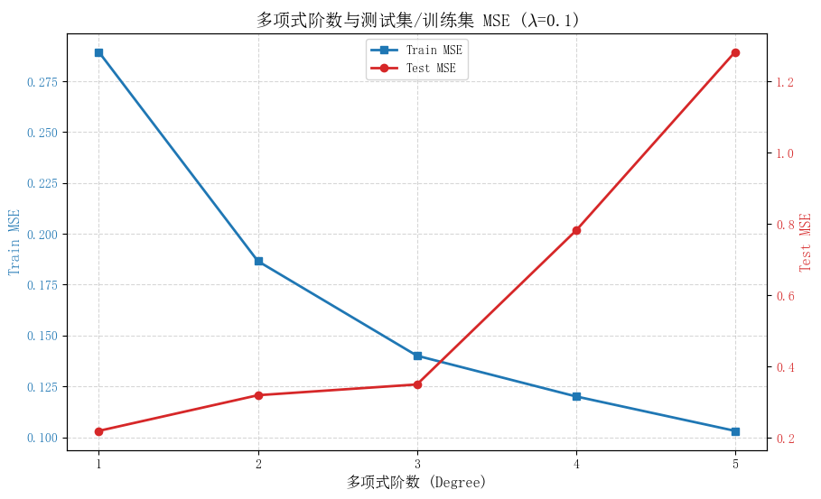

```python
degrees = range(1,6)
lamda = 0.1
train_mses = []
test_mses = []

for deg in degrees:
    W_opt, mu, sigma = solve_W(X_train_raw, y_train, deg, lamda)
    y_train_pred = predict(X_train_raw, W_opt, deg, mu, sigma)
    y_test_pred = predict(X_test_raw, W_opt, deg, mu, sigma)
    train_mses.append(MSE(y_train, y_train_pred))
    test_mses.append(MSE(y_test, y_test_pred))

fig, ax1 = plt.subplots(figsize=(10, 6))

color_train = 'tab:blue'
ax1.set_xlabel('多项式阶数 (Degree)', fontsize=12)
ax1.set_ylabel('Train MSE', color=color_train, fontsize=12)
ax1.plot(degrees, train_mses, color=color_train, marker='s', linewidth=2, label='Train MSE')
ax1.tick_params(axis='y', labelcolor=color_train)
ax1.set_xticks(degrees)
ax1.grid(True, linestyle='--', alpha=0.5)

ax2 = ax1.twinx()
color_test = 'tab:red'
ax2.set_ylabel('Test MSE', color=color_test, fontsize=12)
ax2.plot(degrees, test_mses, color=color_test, marker='o', linewidth=2, label='Test MSE')
ax2.tick_params(axis='y', labelcolor=color_test)

lines1, labels1 = ax1.get_legend_handles_labels()
lines2, labels2 = ax2.get_legend_handles_labels()
ax1.legend(lines1 + lines2, labels1 + labels2, loc='upper center')

ax1.set_title(f'多项式阶数与测试集/训练集 MSE ($\\lambda$={lamda})', fontsize=14)
#fig.tight_layout()
display_inline(fig)
```

可见，随着多项式阶数的增长，训练集 MSE 下降，但测试集 MSE 出现上升. 出现过拟合. 我们增大 $\lambda$ 尝试惩罚过拟合，观察现象

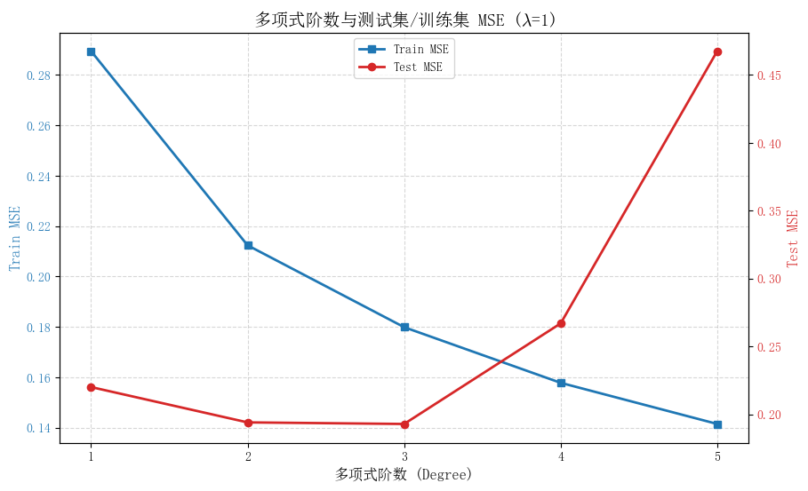

```python
degrees = range(1,6)
lamda = 1
train_mses = []
test_mses = []

for deg in degrees:
    W_opt, mu, sigma = solve_W(X_train_raw, y_train, deg, lamda)
    y_train_pred = predict(X_train_raw, W_opt, deg, mu, sigma)
    y_test_pred = predict(X_test_raw, W_opt, deg, mu, sigma)
    train_mses.append(MSE(y_train, y_train_pred))
    test_mses.append(MSE(y_test, y_test_pred))

fig, ax1 = plt.subplots(figsize=(10, 6))

color_train = 'tab:blue'
ax1.set_xlabel('多项式阶数 (Degree)', fontsize=12)
ax1.set_ylabel('Train MSE', color=color_train, fontsize=12)
ax1.plot(degrees, train_mses, color=color_train, marker='s', linewidth=2, label='Train MSE')
ax1.tick_params(axis='y', labelcolor=color_train)
ax1.set_xticks(degrees)
ax1.grid(True, linestyle='--', alpha=0.5)

ax2 = ax1.twinx()
color_test = 'tab:red'
ax2.set_ylabel('Test MSE', color=color_test, fontsize=12)
ax2.plot(degrees, test_mses, color=color_test, marker='o', linewidth=2, label='Test MSE')
ax2.tick_params(axis='y', labelcolor=color_test)

lines1, labels1 = ax1.get_legend_handles_labels()
lines2, labels2 = ax2.get_legend_handles_labels()
ax1.legend(lines1 + lines2, labels1 + labels2, loc='upper center')

ax1.set_title(f'多项式阶数与测试集/训练集 MSE ($\\lambda$={lamda})', fontsize=14)
#fig.tight_layout()
display_inline(fig)
```

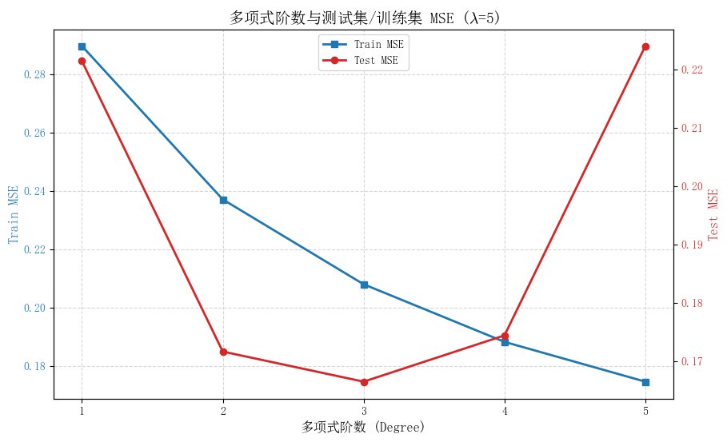

```python
degrees = range(1,6)
lamda = 5
train_mses = []
test_mses = []

for deg in degrees:
    W_opt, mu, sigma = solve_W(X_train_raw, y_train, deg, lamda)
    y_train_pred = predict(X_train_raw, W_opt, deg, mu, sigma)
    y_test_pred = predict(X_test_raw, W_opt, deg, mu, sigma)
    train_mses.append(MSE(y_train, y_train_pred))
    test_mses.append(MSE(y_test, y_test_pred))

fig, ax1 = plt.subplots(figsize=(10, 6))

color_train = 'tab:blue'
ax1.set_xlabel('多项式阶数 (Degree)', fontsize=12)
ax1.set_ylabel('Train MSE', color=color_train, fontsize=12)
ax1.plot(degrees, train_mses, color=color_train, marker='s', linewidth=2, label='Train MSE')
ax1.tick_params(axis='y', labelcolor=color_train)
ax1.set_xticks(degrees)
ax1.grid(True, linestyle='--', alpha=0.5)

ax2 = ax1.twinx()
color_test = 'tab:red'
ax2.set_ylabel('Test MSE', color=color_test, fontsize=12)
ax2.plot(degrees, test_mses, color=color_test, marker='o', linewidth=2, label='Test MSE')
ax2.tick_params(axis='y', labelcolor=color_test)

lines1, labels1 = ax1.get_legend_handles_labels()
lines2, labels2 = ax2.get_legend_handles_labels()
ax1.legend(lines1 + lines2, labels1 + labels2, loc='upper center')

ax1.set_title(f'多项式阶数与测试集/训练集 MSE ($\\lambda$={lamda})', fontsize=14)
#fig.tight_layout()
display_inline(fig)
```

可见，当 $\lambda$ 增大时，基本上当 Degree 为 1,2,3 时 Test MSE 最小.

同时，我们可以注意到，无论是 $\lambda$ 多大，训练集 MSE 都是随多项式阶数单调下降的，但测试集 MSE 基本是先下降再上升，出现欠拟合到过拟合的现象

### L2 正则化系数

下面我们分别就 degree 为 1,2,3 时讨论 $\lambda$ 对训练集 MSE 和测试集 MSE 的影响.

先固定多项式阶数为 1.

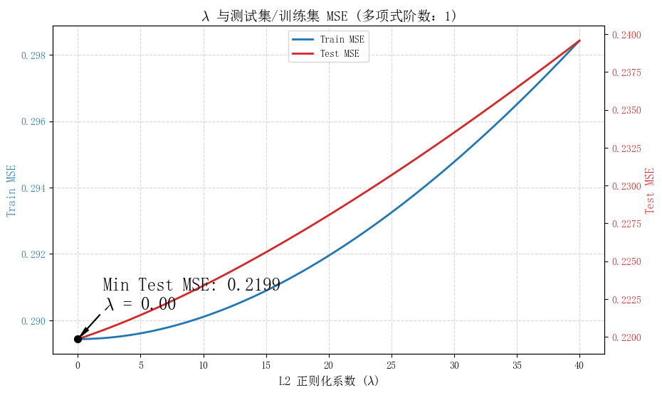

```python
degree = 1
lambdas = np.linspace(0.001, 40, 100)

train_mses = []
test_mses = []

for l in lambdas:
    W_opt, mu, sigma = solve_W(X_train_raw, y_train, degree, l)
    y_train_pred = predict(X_train_raw, W_opt, degree, mu, sigma)
    y_test_pred = predict(X_test_raw, W_opt, degree, mu, sigma)

    train_mses.append(MSE(y_train, y_train_pred))
    test_mses.append(MSE(y_test, y_test_pred))

min_test_mse = min(test_mses)
best_lambda = lambdas[np.argmin(test_mses)]

fig, ax1 = plt.subplots(figsize=(10, 6))

color_train = 'tab:blue'
ax1.set_xlabel(r'L2 正则化系数 ($\lambda$)', fontsize=12)
ax1.set_ylabel('Train MSE', color=color_train, fontsize=12)
ax1.plot(lambdas, train_mses, color=color_train, linewidth=2, label='Train MSE')
ax1.tick_params(axis='y', labelcolor=color_train)
ax1.grid(True, linestyle='--', alpha=0.5)

ax2 = ax1.twinx()
color_test = 'tab:red'
ax2.set_ylabel('Test MSE', color=color_test, fontsize=12)
ax2.plot(lambdas, test_mses, color=color_test, linewidth=2, label='Test MSE')
ax2.tick_params(axis='y', labelcolor=color_test)

ax2.scatter(best_lambda, min_test_mse, color='black', s=50, zorder=5)

lines1, labels1 = ax1.get_legend_handles_labels()
lines2, labels2 = ax2.get_legend_handles_labels()
ax1.legend(lines1 + lines2, labels1 + labels2, loc='upper center')

ax2.annotate(f'Min Test MSE: {min_test_mse:.4f}\n$\\lambda$ = {best_lambda:.2f}',
             xy=(best_lambda, min_test_mse),
             xytext=(best_lambda + 2, min_test_mse + (max(test_mses)-min_test_mse)*0.1),
             arrowprops=dict(facecolor='black', shrink=0.05, width=0.5, headwidth=4),
             fontsize=18, fontweight='bold', color='black')
ax1.set_title(f'$\\lambda$ 与测试集/训练集 MSE (多项式阶数：{degree})', fontsize=14)
display_inline(fig)
```

可见，这里我们注意到，当多项式阶数为 1 时，最小测试集 MSE 出现在 $\lambda=0$（也就是没有 L2 正则化的情况）. 同时，随着 L2 正则化加强，训练集 MSE 和测试集 MSE 都随之增大.

对于 1 阶多项式，我们得到最小的测试集 MSE 为 $0.2199$

下面我们考虑 2 阶多项式

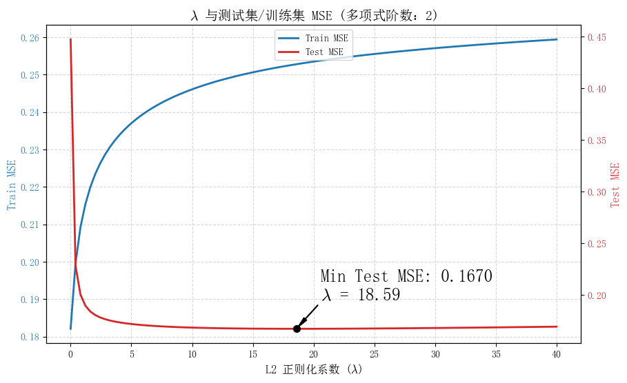

```python
degree = 2
lambdas = np.linspace(0.001, 40, 100)

train_mses = []
test_mses = []

for l in lambdas:
    W_opt, mu, sigma = solve_W(X_train_raw, y_train, degree, l)
    y_train_pred = predict(X_train_raw, W_opt, degree, mu, sigma)
    y_test_pred = predict(X_test_raw, W_opt, degree, mu, sigma)

    train_mses.append(MSE(y_train, y_train_pred))
    test_mses.append(MSE(y_test, y_test_pred))

min_test_mse = min(test_mses)
best_lambda = lambdas[np.argmin(test_mses)]

fig, ax1 = plt.subplots(figsize=(10, 6))

color_train = 'tab:blue'
ax1.set_xlabel(r'L2 正则化系数 ($\lambda$)', fontsize=12)
ax1.set_ylabel('Train MSE', color=color_train, fontsize=12)
ax1.plot(lambdas, train_mses, color=color_train, linewidth=2, label='Train MSE')
ax1.tick_params(axis='y', labelcolor=color_train)
ax1.grid(True, linestyle='--', alpha=0.5)

ax2 = ax1.twinx()
color_test = 'tab:red'
ax2.set_ylabel('Test MSE', color=color_test, fontsize=12)
ax2.plot(lambdas, test_mses, color=color_test, linewidth=2, label='Test MSE')
ax2.tick_params(axis='y', labelcolor=color_test)

ax2.scatter(best_lambda, min_test_mse, color='black', s=50, zorder=5)

lines1, labels1 = ax1.get_legend_handles_labels()
lines2, labels2 = ax2.get_legend_handles_labels()
ax1.legend(lines1 + lines2, labels1 + labels2, loc='upper center')

ax2.annotate(f'Min Test MSE: {min_test_mse:.4f}\n$\\lambda$ = {best_lambda:.2f}',
             xy=(best_lambda, min_test_mse),
             xytext=(best_lambda + 2, min_test_mse + (max(test_mses)-min_test_mse)*0.1),
             arrowprops=dict(facecolor='black', shrink=0.05, width=0.5, headwidth=4),
             fontsize=18, fontweight='bold', color='black')
ax1.set_title(f'$\\lambda$ 与测试集/训练集 MSE (多项式阶数：{degree})', fontsize=14)
display_inline(fig)
```

我们放大后面部分以更好观察曲线后面的趋势

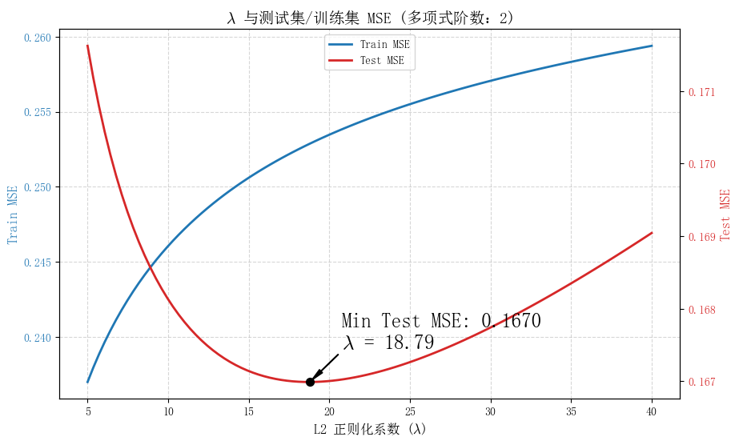

```python
degree = 2
lambdas = np.linspace(5, 40, 100)

train_mses = []
test_mses = []

for l in lambdas:
    W_opt, mu, sigma = solve_W(X_train_raw, y_train, degree, l)
    y_train_pred = predict(X_train_raw, W_opt, degree, mu, sigma)
    y_test_pred = predict(X_test_raw, W_opt, degree, mu, sigma)

    train_mses.append(MSE(y_train, y_train_pred))
    test_mses.append(MSE(y_test, y_test_pred))

min_test_mse = min(test_mses)
best_lambda = lambdas[np.argmin(test_mses)]

fig, ax1 = plt.subplots(figsize=(10, 6))

color_train = 'tab:blue'
ax1.set_xlabel(r'L2 正则化系数 ($\lambda$)', fontsize=12)
ax1.set_ylabel('Train MSE', color=color_train, fontsize=12)
ax1.plot(lambdas, train_mses, color=color_train, linewidth=2, label='Train MSE')
ax1.tick_params(axis='y', labelcolor=color_train)
ax1.grid(True, linestyle='--', alpha=0.5)

ax2 = ax1.twinx()
color_test = 'tab:red'
ax2.set_ylabel('Test MSE', color=color_test, fontsize=12)
ax2.plot(lambdas, test_mses, color=color_test, linewidth=2, label='Test MSE')
ax2.tick_params(axis='y', labelcolor=color_test)

ax2.scatter(best_lambda, min_test_mse, color='black', s=50, zorder=5)

lines1, labels1 = ax1.get_legend_handles_labels()
lines2, labels2 = ax2.get_legend_handles_labels()
ax1.legend(lines1 + lines2, labels1 + labels2, loc='upper center')

ax2.annotate(f'Min Test MSE: {min_test_mse:.4f}\n$\\lambda$ = {best_lambda:.2f}',
             xy=(best_lambda, min_test_mse),
             xytext=(best_lambda + 2, min_test_mse + (max(test_mses)-min_test_mse)*0.1),
             arrowprops=dict(facecolor='black', shrink=0.05, width=0.5, headwidth=4),
             fontsize=18, fontweight='bold', color='black')
ax1.set_title(f'$\\lambda$ 与测试集/训练集 MSE (多项式阶数：{degree})', fontsize=14)
display_inline(fig)
```

上面图像中我们发现，训练集 MSE 随着 $\lambda$ 增大而增大，但测试集 MSE 随 $\lambda$ 增大而先减小后增大. 这与一阶多项式的情况有所区别.

现在我们考虑 3 阶多项式

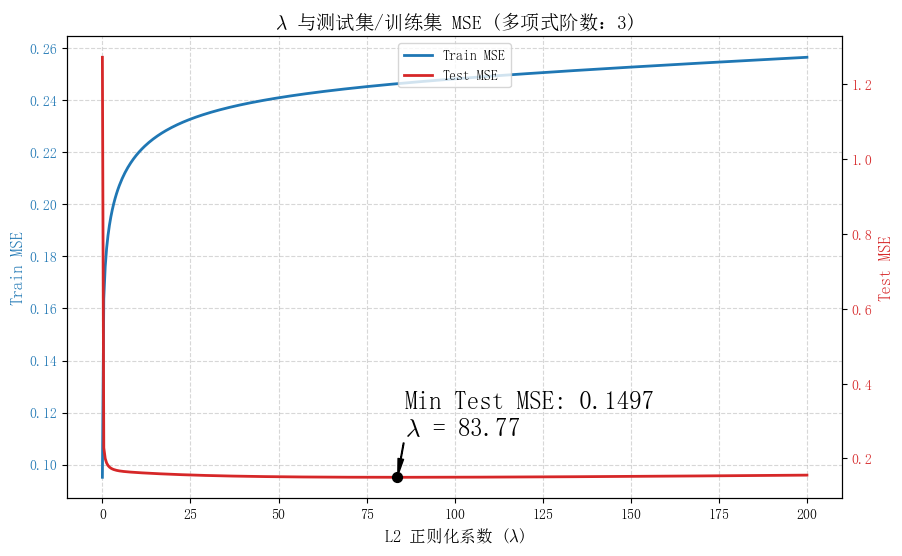

```python
degree = 3
lambdas = np.linspace(0.001, 200, 500)

train_mses = []
test_mses = []

for l in lambdas:
    W_opt, mu, sigma = solve_W(X_train_raw, y_train, degree, l)
    y_train_pred = predict(X_train_raw, W_opt, degree, mu, sigma)
    y_test_pred = predict(X_test_raw, W_opt, degree, mu, sigma)

    train_mses.append(MSE(y_train, y_train_pred))
    test_mses.append(MSE(y_test, y_test_pred))

min_test_mse = min(test_mses)
best_lambda = lambdas[np.argmin(test_mses)]

fig, ax1 = plt.subplots(figsize=(10, 6))

color_train = 'tab:blue'
ax1.set_xlabel(r'L2 正则化系数 ($\lambda$)', fontsize=12)
ax1.set_ylabel('Train MSE', color=color_train, fontsize=12)
ax1.plot(lambdas, train_mses, color=color_train, linewidth=2, label='Train MSE')
ax1.tick_params(axis='y', labelcolor=color_train)
ax1.grid(True, linestyle='--', alpha=0.5)

ax2 = ax1.twinx()
color_test = 'tab:red'
ax2.set_ylabel('Test MSE', color=color_test, fontsize=12)
ax2.plot(lambdas, test_mses, color=color_test, linewidth=2, label='Test MSE')
ax2.tick_params(axis='y', labelcolor=color_test)

ax2.scatter(best_lambda, min_test_mse, color='black', s=50, zorder=5)

lines1, labels1 = ax1.get_legend_handles_labels()
lines2, labels2 = ax2.get_legend_handles_labels()
ax1.legend(lines1 + lines2, labels1 + labels2, loc='upper center')

ax2.annotate(f'Min Test MSE: {min_test_mse:.4f}\n$\\lambda$ = {best_lambda:.2f}',
             xy=(best_lambda, min_test_mse),
             xytext=(best_lambda + 2, min_test_mse + (max(test_mses)-min_test_mse)*0.1),
             arrowprops=dict(facecolor='black', shrink=0.05, width=0.5, headwidth=4),
             fontsize=18, fontweight='bold', color='black')
ax1.set_title(f'$\\lambda$ 与测试集/训练集 MSE (多项式阶数：{degree})', fontsize=14)
display_inline(fig)
```

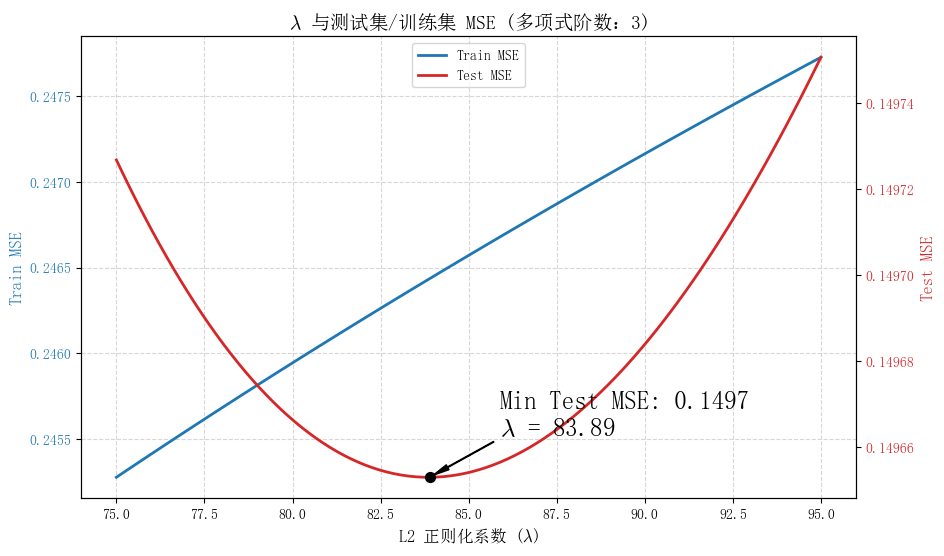

```python
degree = 3
lambdas = np.linspace(75, 95, 100)

train_mses = []
test_mses = []

for l in lambdas:
    W_opt, mu, sigma = solve_W(X_train_raw, y_train, degree, l)
    y_train_pred = predict(X_train_raw, W_opt, degree, mu, sigma)
    y_test_pred = predict(X_test_raw, W_opt, degree, mu, sigma)

    train_mses.append(MSE(y_train, y_train_pred))
    test_mses.append(MSE(y_test, y_test_pred))

min_test_mse = min(test_mses)
best_lambda = lambdas[np.argmin(test_mses)]

fig, ax1 = plt.subplots(figsize=(10, 6))

color_train = 'tab:blue'
ax1.set_xlabel(r'L2 正则化系数 ($\lambda$)', fontsize=12)
ax1.set_ylabel('Train MSE', color=color_train, fontsize=12)
ax1.plot(lambdas, train_mses, color=color_train, linewidth=2, label='Train MSE')
ax1.tick_params(axis='y', labelcolor=color_train)
ax1.grid(True, linestyle='--', alpha=0.5)

ax2 = ax1.twinx()
color_test = 'tab:red'
ax2.set_ylabel('Test MSE', color=color_test, fontsize=12)
ax2.plot(lambdas, test_mses, color=color_test, linewidth=2, label='Test MSE')
ax2.tick_params(axis='y', labelcolor=color_test)

ax2.scatter(best_lambda, min_test_mse, color='black', s=50, zorder=5)

lines1, labels1 = ax1.get_legend_handles_labels()
lines2, labels2 = ax2.get_legend_handles_labels()
ax1.legend(lines1 + lines2, labels1 + labels2, loc='upper center')

ax2.annotate(f'Min Test MSE: {min_test_mse:.4f}\n$\\lambda$ = {best_lambda:.2f}',
             xy=(best_lambda, min_test_mse),
             xytext=(best_lambda + 2, min_test_mse + (max(test_mses)-min_test_mse)*0.1),
             arrowprops=dict(facecolor='black', shrink=0.05, width=0.5, headwidth=4),
             fontsize=18, fontweight='bold', color='black')
ax1.set_title(f'$\\lambda$ 与测试集/训练集 MSE (多项式阶数：{degree})', fontsize=14)
display_inline(fig)
```

在上面图像中我们发现，训练集 MSE 随着 $\lambda$ 增大而增大，但测试集 MSE 随 $\lambda$ 增大而先减小后增大.

对于 3 阶多项式，当 $\lambda=83.89$ 时. 测试集 MSE 最小，为 $0.1497$

同时，我们可以注意到，随着多项式阶数增大，最优的 L2 正则化系数 $\lambda$ 越大.

另外，我们观察到，就目前而言，随着多项式阶数的增加，最优测试集 MSE 越小. 虽然前面大致知道最优多项式阶数大概在 1,2,3 之中，但为了保险起见，我们多讨论多项式阶数为 4 的情况

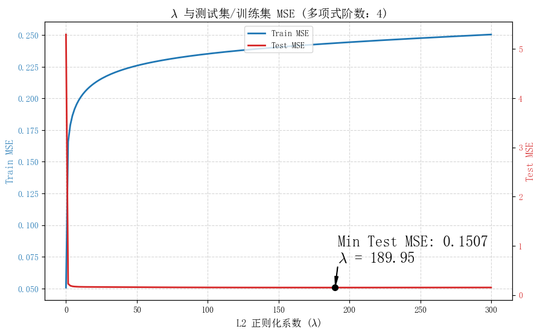

```python
degree = 4
lambdas = np.linspace(0.001, 300, 200)

train_mses = []
test_mses = []

for l in lambdas:
    W_opt, mu, sigma = solve_W(X_train_raw, y_train, degree, l)
    y_train_pred = predict(X_train_raw, W_opt, degree, mu, sigma)
    y_test_pred = predict(X_test_raw, W_opt, degree, mu, sigma)

    train_mses.append(MSE(y_train, y_train_pred))
    test_mses.append(MSE(y_test, y_test_pred))

min_test_mse = min(test_mses)
best_lambda = lambdas[np.argmin(test_mses)]

fig, ax1 = plt.subplots(figsize=(10, 6))

color_train = 'tab:blue'
ax1.set_xlabel(r'L2 正则化系数 ($\lambda$)', fontsize=12)
ax1.set_ylabel('Train MSE', color=color_train, fontsize=12)
ax1.plot(lambdas, train_mses, color=color_train, linewidth=2, label='Train MSE')
ax1.tick_params(axis='y', labelcolor=color_train)
ax1.grid(True, linestyle='--', alpha=0.5)

ax2 = ax1.twinx()
color_test = 'tab:red'
ax2.set_ylabel('Test MSE', color=color_test, fontsize=12)
ax2.plot(lambdas, test_mses, color=color_test, linewidth=2, label='Test MSE')
ax2.tick_params(axis='y', labelcolor=color_test)

ax2.scatter(best_lambda, min_test_mse, color='black', s=50, zorder=5)

lines1, labels1 = ax1.get_legend_handles_labels()
lines2, labels2 = ax2.get_legend_handles_labels()
ax1.legend(lines1 + lines2, labels1 + labels2, loc='upper center')

ax2.annotate(f'Min Test MSE: {min_test_mse:.4f}\n$\\lambda$ = {best_lambda:.2f}',
             xy=(best_lambda, min_test_mse),
             xytext=(best_lambda + 2, min_test_mse + (max(test_mses)-min_test_mse)*0.1),
             arrowprops=dict(facecolor='black', shrink=0.05, width=0.5, headwidth=4),
             fontsize=18, fontweight='bold', color='black')
ax1.set_title(f'$\\lambda$ 与测试集/训练集 MSE (多项式阶数：{degree})', fontsize=14)
display_inline(fig)
```

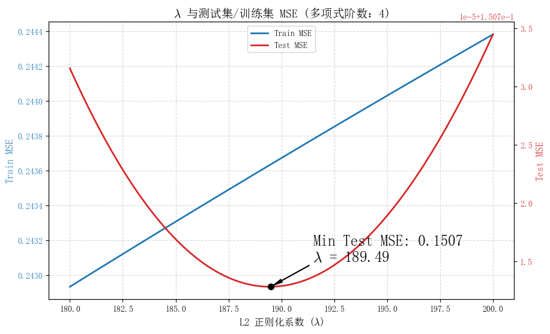

```python
degree = 4
lambdas = np.linspace(180, 200, 100)

train_mses = []
test_mses = []

for l in lambdas:
    W_opt, mu, sigma = solve_W(X_train_raw, y_train, degree, l)
    y_train_pred = predict(X_train_raw, W_opt, degree, mu, sigma)
    y_test_pred = predict(X_test_raw, W_opt, degree, mu, sigma)

    train_mses.append(MSE(y_train, y_train_pred))
    test_mses.append(MSE(y_test, y_test_pred))

min_test_mse = min(test_mses)
best_lambda = lambdas[np.argmin(test_mses)]

fig, ax1 = plt.subplots(figsize=(10, 6))

color_train = 'tab:blue'
ax1.set_xlabel(r'L2 正则化系数 ($\lambda$)', fontsize=12)
ax1.set_ylabel('Train MSE', color=color_train, fontsize=12)
ax1.plot(lambdas, train_mses, color=color_train, linewidth=2, label='Train MSE')
ax1.tick_params(axis='y', labelcolor=color_train)
ax1.grid(True, linestyle='--', alpha=0.5)

ax2 = ax1.twinx()
color_test = 'tab:red'
ax2.set_ylabel('Test MSE', color=color_test, fontsize=12)
ax2.plot(lambdas, test_mses, color=color_test, linewidth=2, label='Test MSE')
ax2.tick_params(axis='y', labelcolor=color_test)

ax2.scatter(best_lambda, min_test_mse, color='black', s=50, zorder=5)

lines1, labels1 = ax1.get_legend_handles_labels()
lines2, labels2 = ax2.get_legend_handles_labels()
ax1.legend(lines1 + lines2, labels1 + labels2, loc='upper center')

ax2.annotate(f'Min Test MSE: {min_test_mse:.4f}\n$\\lambda$ = {best_lambda:.2f}',
             xy=(best_lambda, min_test_mse),
             xytext=(best_lambda + 2, min_test_mse + (max(test_mses)-min_test_mse)*0.1),
             arrowprops=dict(facecolor='black', shrink=0.05, width=0.5, headwidth=4),
             fontsize=18, fontweight='bold', color='black')
ax1.set_title(f'$\\lambda$ 与测试集/训练集 MSE (多项式阶数：{degree})', fontsize=14)
display_inline(fig)
```

在上面图像中我们发现，训练集 MSE 随着 $\lambda$ 增大而增大，但测试集 MSE 随 $\lambda$ 增大而先减小后增大.

对于 4 阶多项式，当 $\lambda=189.49$ 时. 测试集 MSE 最小，为 $0.1507$

综上：

[output not shown]

可见，最优 L2 正则化系数随多项式阶数的增大而增大. 这是符合预期的，因为多项式阶数越大，模型拟合能力越强，为了使得模型不过拟合，就需要越大的 L2 正则化系数

### 学习率

下面我们使用梯度下降法进行优化. 取 3 阶多项式，$\lambda=89.93$. 探究学习率 $\alpha$ 和训练集 MSE 和测试集 MSE 关系. 我们统一取 1000 轮.

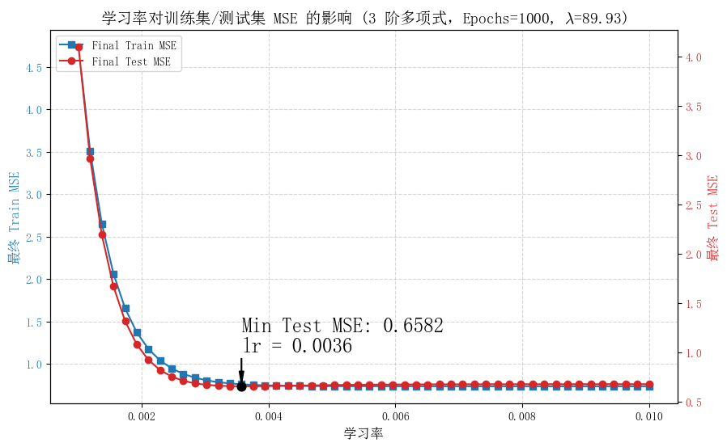

```python
degree = 3
lamda = 89.93
epochs = 1000
lrs = np.linspace(0.001, 0.01, 50)

train_mses = []
test_mses = []

for lr in lrs:
    W_opt, mu, sigma, train_hist, test_hist = train(
        X_train_raw, y_train, X_test_raw, y_test,
        degree=degree, lr=lr, epochs=epochs, lamda=lamda
    )

    y_tr_pred = predict(X_train_raw, W_opt, degree, mu, sigma)
    y_te_pred = predict(X_test_raw, W_opt, degree, mu, sigma)
    train_mses.append(MSE(y_train, y_tr_pred))
    test_mses.append(MSE(y_test, y_te_pred))

min_test_mse = min(test_mses)
best_lr = lrs[np.argmin(test_mses)]

fig, ax1 = plt.subplots(figsize=(10, 6))

color_train = 'tab:blue'
ax1.set_xlabel('学习率', fontsize=12)
ax1.set_ylabel('最终 Train MSE', color=color_train, fontsize=12)
ax1.plot(lrs, train_mses, color=color_train, marker='s', label='Final Train MSE')
ax1.tick_params(axis='y', labelcolor=color_train)
ax1.grid(True, linestyle='--', alpha=0.5)

ax2 = ax1.twinx()
color_test = 'tab:red'
ax2.set_ylabel('最终 Test MSE', color=color_test, fontsize=12)
ax2.plot(lrs, test_mses, color=color_test, marker='o', label='Final Test MSE')
ax2.tick_params(axis='y', labelcolor=color_test)

ax1.set_title(f'学习率对训练集/测试集 MSE 的影响 (3 阶多项式，Epochs={epochs}, $\\lambda$={lamda})', fontsize=14)
lines1, labels1 = ax1.get_legend_handles_labels()
lines2, labels2 = ax2.get_legend_handles_labels()
ax1.legend(lines1 + lines2, labels1 + labels2, loc='upper left')

ax2.scatter(best_lr, min_test_mse, color='black', s=60, zorder=5)

ax2.annotate(f'Min Test MSE: {min_test_mse:.4f}\nlr = {best_lr:.4f}',
             xy=(best_lr, min_test_mse),
             xytext=(best_lr, min_test_mse + (max(test_mses)-min_test_mse)*0.1),
             arrowprops=dict(facecolor='black', shrink=0.05, width=0.5, headwidth=4),
             fontsize=18, fontweight='bold', color='black')

display_inline(fig)
```

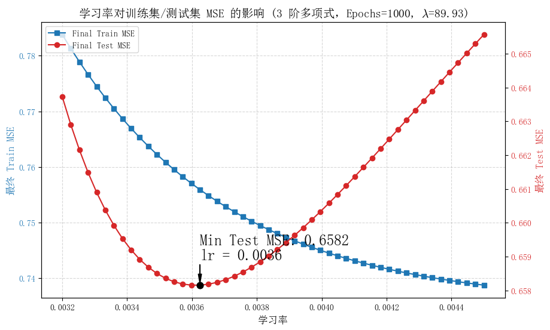

```python
degree = 3
lamda = 89.93
epochs = 1000
lrs = np.linspace(0.0032, 0.0045, 50)

train_mses = []
test_mses = []

for lr in lrs:
    W_opt, mu, sigma, train_hist, test_hist = train(
        X_train_raw, y_train, X_test_raw, y_test,
        degree=degree, lr=lr, epochs=epochs, lamda=lamda
    )

    y_tr_pred = predict(X_train_raw, W_opt, degree, mu, sigma)
    y_te_pred = predict(X_test_raw, W_opt, degree, mu, sigma)
    train_mses.append(MSE(y_train, y_tr_pred))
    test_mses.append(MSE(y_test, y_te_pred))

min_test_mse = min(test_mses)
best_lr = lrs[np.argmin(test_mses)]

fig, ax1 = plt.subplots(figsize=(10, 6))

color_train = 'tab:blue'
ax1.set_xlabel('学习率', fontsize=12)
ax1.set_ylabel('最终 Train MSE', color=color_train, fontsize=12)
ax1.plot(lrs, train_mses, color=color_train, marker='s', label='Final Train MSE')
ax1.tick_params(axis='y', labelcolor=color_train)
ax1.grid(True, linestyle='--', alpha=0.5)

ax2 = ax1.twinx()
color_test = 'tab:red'
ax2.set_ylabel('最终 Test MSE', color=color_test, fontsize=12)
ax2.plot(lrs, test_mses, color=color_test, marker='o', label='Final Test MSE')
ax2.tick_params(axis='y', labelcolor=color_test)

ax1.set_title(f'学习率对训练集/测试集 MSE 的影响 (3 阶多项式，Epochs={epochs}, $\\lambda$={lamda})', fontsize=14)
lines1, labels1 = ax1.get_legend_handles_labels()
lines2, labels2 = ax2.get_legend_handles_labels()
ax1.legend(lines1 + lines2, labels1 + labels2, loc='upper left')

ax2.scatter(best_lr, min_test_mse, color='black', s=60, zorder=5)

ax2.annotate(f'Min Test MSE: {min_test_mse:.4f}\nlr = {best_lr:.4f}',
             xy=(best_lr, min_test_mse),
             xytext=(best_lr, min_test_mse + (max(test_mses)-min_test_mse)*0.1),
             arrowprops=dict(facecolor='black', shrink=0.05, width=0.5, headwidth=4),
             fontsize=18, fontweight='bold', color='black')

display_inline(fig)
```

我们改变训练轮数，观察

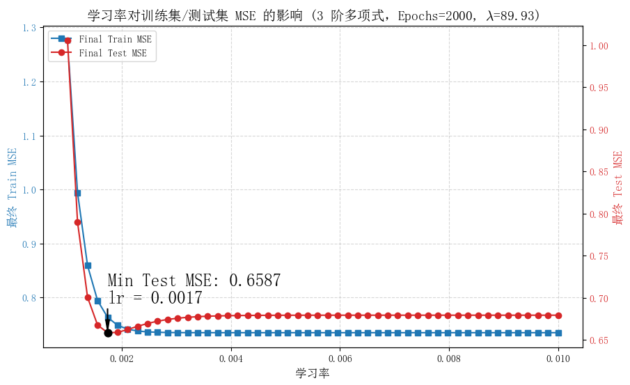

```python
degree = 3
lamda = 89.93
epochs = 2000
lrs = np.linspace(0.001, 0.01, 50)

train_mses = []
test_mses = []

for lr in lrs:
    W_opt, mu, sigma, train_hist, test_hist = train(
        X_train_raw, y_train, X_test_raw, y_test,
        degree=degree, lr=lr, epochs=epochs, lamda=lamda
    )

    y_tr_pred = predict(X_train_raw, W_opt, degree, mu, sigma)
    y_te_pred = predict(X_test_raw, W_opt, degree, mu, sigma)
    train_mses.append(MSE(y_train, y_tr_pred))
    test_mses.append(MSE(y_test, y_te_pred))

min_test_mse = min(test_mses)
best_lr = lrs[np.argmin(test_mses)]

fig, ax1 = plt.subplots(figsize=(10, 6))

color_train = 'tab:blue'
ax1.set_xlabel('学习率', fontsize=12)
ax1.set_ylabel('最终 Train MSE', color=color_train, fontsize=12)
ax1.plot(lrs, train_mses, color=color_train, marker='s', label='Final Train MSE')
ax1.tick_params(axis='y', labelcolor=color_train)
ax1.grid(True, linestyle='--', alpha=0.5)

ax2 = ax1.twinx()
color_test = 'tab:red'
ax2.set_ylabel('最终 Test MSE', color=color_test, fontsize=12)
ax2.plot(lrs, test_mses, color=color_test, marker='o', label='Final Test MSE')
ax2.tick_params(axis='y', labelcolor=color_test)

ax1.set_title(f'学习率对训练集/测试集 MSE 的影响 (3 阶多项式，Epochs={epochs}, $\\lambda$={lamda})', fontsize=14)
lines1, labels1 = ax1.get_legend_handles_labels()
lines2, labels2 = ax2.get_legend_handles_labels()
ax1.legend(lines1 + lines2, labels1 + labels2, loc='upper left')

ax2.scatter(best_lr, min_test_mse, color='black', s=60, zorder=5)

ax2.annotate(f'Min Test MSE: {min_test_mse:.4f}\nlr = {best_lr:.4f}',
             xy=(best_lr, min_test_mse),
             xytext=(best_lr, min_test_mse + (max(test_mses)-min_test_mse)*0.1),
             arrowprops=dict(facecolor='black', shrink=0.05, width=0.5, headwidth=4),
             fontsize=18, fontweight='bold', color='black')

display_inline(fig)
```

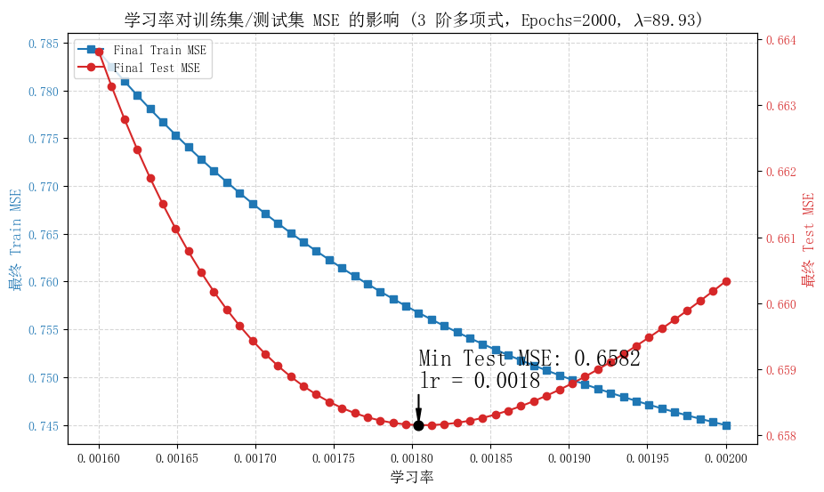

```python
degree = 3
lamda = 89.93
epochs = 2000
lrs = np.linspace(0.0016, 0.002, 50)

train_mses = []
test_mses = []

for lr in lrs:
    W_opt, mu, sigma, train_hist, test_hist = train(
        X_train_raw, y_train, X_test_raw, y_test,
        degree=degree, lr=lr, epochs=epochs, lamda=lamda
    )

    y_tr_pred = predict(X_train_raw, W_opt, degree, mu, sigma)
    y_te_pred = predict(X_test_raw, W_opt, degree, mu, sigma)
    train_mses.append(MSE(y_train, y_tr_pred))
    test_mses.append(MSE(y_test, y_te_pred))

min_test_mse = min(test_mses)
best_lr = lrs[np.argmin(test_mses)]

fig, ax1 = plt.subplots(figsize=(10, 6))

color_train = 'tab:blue'
ax1.set_xlabel('学习率', fontsize=12)
ax1.set_ylabel('最终 Train MSE', color=color_train, fontsize=12)
ax1.plot(lrs, train_mses, color=color_train, marker='s', label='Final Train MSE')
ax1.tick_params(axis='y', labelcolor=color_train)
ax1.grid(True, linestyle='--', alpha=0.5)

ax2 = ax1.twinx()
color_test = 'tab:red'
ax2.set_ylabel('最终 Test MSE', color=color_test, fontsize=12)
ax2.plot(lrs, test_mses, color=color_test, marker='o', label='Final Test MSE')
ax2.tick_params(axis='y', labelcolor=color_test)

ax1.set_title(f'学习率对训练集/测试集 MSE 的影响 (3 阶多项式，Epochs={epochs}, $\\lambda$={lamda})', fontsize=14)
lines1, labels1 = ax1.get_legend_handles_labels()
lines2, labels2 = ax2.get_legend_handles_labels()
ax1.legend(lines1 + lines2, labels1 + labels2, loc='upper left')

ax2.scatter(best_lr, min_test_mse, color='black', s=60, zorder=5)

ax2.annotate(f'Min Test MSE: {min_test_mse:.4f}\nlr = {best_lr:.4f}',
             xy=(best_lr, min_test_mse),
             xytext=(best_lr, min_test_mse + (max(test_mses)-min_test_mse)*0.1),
             arrowprops=dict(facecolor='black', shrink=0.05, width=0.5, headwidth=4),
             fontsize=18, fontweight='bold', color='black')

display_inline(fig)
```

可见，Test MSE 随学习率先下降后上升，同时随着 Epochs 增大，最优学习率减小. 这是因为当学习率较小时，指定 Epochs 后仍旧没有达到最优. 学习率较大时，系统在 Loss 最小值附近振荡，而不能收敛到最小值.

由于梯度下降得到的结果没有前面使用正规方程+L2 正则化解析求解好，因此后面我们还是使用最优的通过正规方程+L2 正则化解析求解得到的模型

## 结果可视化和结论

我们令横轴为国家排名，竖轴为分数，绘制预测分数和实际分数曲线.

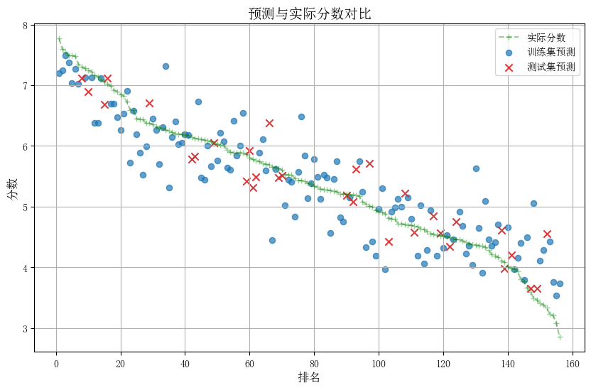

```python
degree = 3
lamda = 83.89
W_opt, mu, sigma = solve_W(X_train_raw, y_train, degree, lamda)

y_train_pred = predict(X_train_raw, W_opt, degree, mu, sigma).flatten()
y_test_pred = predict(X_test_raw, W_opt, degree, mu, sigma).flatten()

train_data = np.column_stack([y_train.flatten(), y_train_pred, np.zeros_like(y_train_pred)])
test_data = np.column_stack([y_test.flatten(), y_test_pred, np.ones_like(y_test_pred)])
all_data = np.vstack([train_data, test_data])

sort_idx = np.argsort(all_data[:, 0])[::-1]
sorted_all = all_data[sort_idx]

y_true_sorted = sorted_all[:, 0]
y_pred_sorted = sorted_all[:, 1]
set_type_sorted = sorted_all[:, 2]
ranks = np.arange(1, len(y_true_sorted) + 1)

fig, ax = plt.subplots(figsize=(10, 6))
ax.plot(ranks, y_true_sorted, 'g--+', alpha=0.4, label='实际分数')

train_mask = (set_type_sorted == 0)
ax.scatter(ranks[train_mask], y_pred_sorted[train_mask],
           color='tab:blue', marker='o', s=35, label='训练集预测', alpha=0.7)

test_mask = (set_type_sorted == 1)
ax.scatter(ranks[test_mask], y_pred_sorted[test_mask],
           color='tab:red', marker='x', s=55, label='测试集预测', alpha=0.9)

ax.set_title(r'预测与实际分数对比', fontsize=14)
ax.set_xlabel('排名', fontsize=12)
ax.set_ylabel('分数', fontsize=12)
ax.grid()
ax.legend(loc='upper right')
display_inline(fig)
```

可见，就趋势而言，预测结果和实际结果是相近的. 但预测结果和实际结果均有一定的误差. 也许可以通过修改模型，引入 $\exp$ 函数之类的新的特征进行优化.

下面我们分析权重，我们打印最大的 15 个权重并”翻译“回对应的特征：

```python
def get_params(all_features, W, degree):
    feature_names = ['Bias']

    n = len(all_features)
    for d in range(1, degree + 1):
        for c in combinations_with_replacement(range(n), d):
            name = " * ".join([all_features[i] for i in c])
            feature_names.append(name)
    params = []
    for name, weight in zip(feature_names, W):
        params.append({
            'name': name,
            'weight': weight,
        })
    return sorted(params, key=lambda x: x['weight'], reverse=True)

params = get_params(all_features, W_opt, degree=3)

print(f"{'特征':<81} | {'权重':<15}")
print("-" * 95)
for p in params[:15]:
    print(f"{p['name']:<82} | {p['weight']:<15.8f}")
```

```
特征                                                                                | 权重
-----------------------------------------------------------------------------------------------
Bias                                                                               | 5.44090323
Social support * Social support * Healthy life expectancy                          | 0.05426375
Social support * Healthy life expectancy * Healthy life expectancy                 | 0.04702320
Social support * Healthy life expectancy                                           | 0.04689450
GDP per capita * Social support * Social support                                   | 0.04372473
Social support * Social support * Social support                                   | 0.04165458
GDP per capita * Social support * Healthy life expectancy                          | 0.04152100
Social support                                                                     | 0.03946178
Social support * Social support                                                    | 0.03829687
Social support * Social support * Freedom to make life choices                     | 0.03659430
GDP per capita * Social support                                                    | 0.03571805
Social support * Healthy life expectancy * Freedom to make life choices            | 0.03536945
Freedom to make life choices                                                       | 0.03534211
Healthy life expectancy * Healthy life expectancy                                  | 0.03450784
Social support * Freedom to make life choices                                      | 0.03435619
```

最小的 15 个特征为：

```python
def get_params(all_features, W, degree):
    feature_names = ['Bias']

    n = len(all_features)
    for d in range(1, degree + 1):
        for c in combinations_with_replacement(range(n), d):
            name = " * ".join([all_features[i] for i in c])
            feature_names.append(name)
    params = []
    for name, weight in zip(feature_names, W):
        params.append({
            'name': name,
            'weight': weight,
        })
    return sorted(params, key=lambda x: x['weight'], reverse=True)

params = get_params(all_features, W_opt, degree=3)

print(f"{'特征':<80} | {'权重':<15}")
print("-" * 96)
for p in params[-15:]:
    print(f"{p['name']:<82} | {p['weight']:<15.8f}")
```

```
特征                                                                               | 权重
------------------------------------------------------------------------------------------------
GDP per capita * Generosity * Perceptions of corruption                            | -0.00739465
Generosity * Perceptions of corruption * Perceptions of corruption                 | -0.00767424
Perceptions of corruption * Perceptions of corruption * Perceptions of corruption  | -0.00800672
GDP per capita * Perceptions of corruption                                         | -0.00813460
GDP per capita * GDP per capita * Perceptions of corruption                        | -0.01066556
Healthy life expectancy * Generosity * Perceptions of corruption                   | -0.01088422
GDP per capita * Healthy life expectancy * Perceptions of corruption               | -0.01198736
Healthy life expectancy * Healthy life expectancy * Perceptions of corruption      | -0.01361401
Healthy life expectancy * Perceptions of corruption * Perceptions of corruption    | -0.01432556
GDP per capita * Perceptions of corruption * Perceptions of corruption             | -0.01505577
Generosity * Generosity * Perceptions of corruption                                | -0.01584788
Freedom to make life choices * Generosity * Generosity                             | -0.01742901
Healthy life expectancy * Generosity * Generosity                                  | -0.01846652
Generosity * Generosity                                                            | -0.02035884
Generosity * Generosity * Generosity                                               | -0.03312265
```

从中我们可以发现，对于幸福指数，Social support（社会支持）是影响力最大的部分. 提升社会支持能较好地提升幸福指数.

另一方面，权重最高的几项如 Social support * Social support * Healthy life expectancy 说明，当社会支持与医疗健康水平同时提升时，幸福指数能提高.

Generosity（慷慨） 和 Perceptions of corruption（腐败感知） 的多项组合呈现负权重. 说明降低腐败感知（即提高廉洁度）能提升幸福指数. Generosity 出现负权重可能是因为 Generosity 与 Perceptions of corruption 存在一定相关性.

## 结论

这里我们就 `2019Happy.csv` 数据集进行了拟合和分析. 这里我们使用正规方程+L2正规化求解和梯度下降法优化. 并尝试给出最优的超参.

对于正规方程+L2正规化，我们有：

[output not shown]

并得到最优超参为：3阶多项式，L2 正则化系数为 83.89

同时，我们注意到，最优 L2 正则化系数随多项式阶数的增大而增大. 这是符合预期的，因为多项式阶数越大，模型拟合能力越强，为了使得模型不过拟合，就需要越大的 L2 正则化系数

另一方面，我们探究了学习率和模型测试集 MSE 的关系：Test MSE 随学习率先下降后上升，同时随着 Epochs 增大，最优学习率减小. 这是因为当学习率较小时，指定 Epochs 后仍旧没有达到最优. 学习率较大时，系统在 Loss 最小值附近振荡，而不能收敛到最小值.

最后，我们通过分析权重得到影响幸福指数的参数. 要提升幸福指数，需要提升 Social support, Healthy life expectancy, GDP per capita, 减小 Perceptions of corruption.

## 参考资料

- 部分代码编写时使用 Fitten Code AI 进行补全
- 代码实现中使用 Google Gemini AI 查询了一些函数的用法.

## 致谢

暂无

## 附一：问题

- 是否能通过引入 $\exp$ 等特征来给出更好的模型.
- 是否能通过增大阶数+更大的 L2 正则化系数来得到更好的模型.
- L2 正则化系数对损失函数的“形状”的影响？

## 附二：学习心得

- 带有 L2 正则化的线性回归以及其解析求解（使用伪逆的求解）
- 特征标准化